# Hands-On Programming with R

Summarizing series from excellent authors

Cevi Herdian

See the change log update

[figure not shown]

**Note:**

-An R Notebook is an R Markdown document with chunks that can be executed independently and interactively, with output visible immediately beneath the input.

-Notebook output are available as HTML, PDF, Word, or Latex.

-This Notebook as HTML is preferably open with Google Chrome.

-R-Code can be extracted as Rmd file under the button “Code” in the notebook.

-This Notebook using iterative development. It means the process starts with a simple implementation of a small set of idea requirements and iteratively enhances the evolving versions until the complete version is implemented and perfect.

# Getting started

[figure not shown]

```r
#https://rstudio-education.github.io/hopr/
```

This book are:

- Teach you how to program in R, with hands-on examples
- A friendly introduction to the R language
- Newfound skills to solve practical data science problems
- Go from loading data to writing your own functions
- Help you become a data scientist, as well as a computer scientist
- Focus on the programming skills that are most related to data science
- Treat R purely as a programming language

# ==Project 1: Weighted Dice==

Improve your ability as a data scientist:

- Memorize (store) entire data sets
- Recall data values on demand
- Perform complex calculations with large amounts of data
- Do repetitive tasks without becoming careless or bored

Your first mission is simple: assemble R code that will simulate rolling a pair of dice, like at a craps table. In this project, you will learn how to:

- Use the R and RStudio interfaces
- Run R commands
- Create R objects
- Write your own R functions and scripts
- Load and use R packages
- Generate random samples
- Create quick plots
- Get help when you need it

You’ll need to have both R and RStudio installed on your computer before you can use them. Both are free and easy to download. See **Appendix A**

# 1. The Very Basics

In it, you will build a pair of virtual dice that you can use to generate random numbers.

**The R User Interface:**

[figure not shown]

```r
#https://rstudio-education.github.io/hopr/basics.html#the-r-user-interface
```

> If you do not yet have R and RStudio intalled on your computer-or do not know what I am talking about-visit Appendix A. The appendix will give you an overview of the two free tools and tell you how to download them.

When you type a command at the prompt and hit Enter, your computer executes the command and shows you the results. Then RStudio displays a fresh prompt for your next command. For example, if you type 1 + 1 and hit Enter, RStudio will display:

```r
1 + 1
```

```
[1] 2
```

You can mostly ignore the numbers that appear in brackets:

```r
100:130
```

```
 [1] 100 101 102 103 104 105 106 107 108 109 110 111 112 113 114 115 116 117 118 119 120 121 122
[24] 123 124 125 126 127 128 129 130
```

If you type an incomplete command and press Enter, R will display a + prompt, which means R is waiting for you to type the rest of your command. Either finish the command or hit Escape to start over:

```r
5 -
```

```
Error: Incomplete expression: 5 -
```

If you type a command that R doesn’t recognize, R will return an error message. If you ever see an error message, don’t panic. R is just telling you that your computer couldn’t understand or do what you asked it to do.

```r
3 % 5
```

```
Error: unexpected input in "3 % 5"
```

Once you get the hang of the command line, you can easily do anything in R that you would do with a calculator. For example, you could do some basic arithmetic:

```r
2 * 3
```

```
[1] 6
```

```r
4 - 1
```

```
[1] 3
```

```r
6 / (4 - 1)
```

```
[1] 2
```

____Exercise_The R User Interface:

1. Choose any number and add 2 to it.
2. Multiply the result by 3.
3. Subtract 6 from the answer.
4. Divide what you get by 3.

Solution:

```r
10 + 2
```

```
[1] 12
```

```r
## 12
12 * 3
```

```
[1] 36
```

```r
## 36
36 - 6
```

```
[1] 30
```

```r
## 30
30 / 3
```

```
[1] 10
```

```r
## 10
```

**Objects:**

R lets you save data by storing it inside an R object. What’s an object? Just a name that you can use to call up stored data.

```r
a <- 1
a
```

```
[1] 1
```

```r
die <- 1:6
die
```

```
[1] 1 2 3 4 5 6
```

[figure not shown]

```r
#https://rstudio-education.github.io/hopr/basics.html#objects
```

R also understands capitalization (or is case-sensitive), so name and Name will refer to different objects:

```r
Name <- 1
Name
```

```
[1] 1
```

```r
name <- 0
name
```

```
[1] 0
```

You can see which object names you have already used with the function `ls`:

```r
ls()
```

```
[1] "a"    "die"  "name" "Name"
```

If you are a big fan of linear algebra (and who isn’t?), you may notice that R does not always follow the rules of matrix multiplication. Instead, R uses element-wise execution. When you manipulate a set of numbers, R will apply the same operation to each element in the set. So for example, when you run die - 1, R subtracts one from each element of die.

The result will be a new vector the same length as the first two, as shown in Figure 1-3.

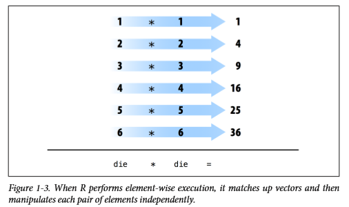

```r
#https://rstudio-education.github.io/hopr/basics.html#objects
```

If you give R two vectors of unequal lengths, R will repeat the shorter vector until it is as long as the longer vector, and then do the math, as shown in Figure 1-4.

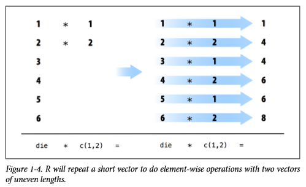

```r
#https://rstudio-education.github.io/hopr/basics.html#objects
```

But don’t think that R has given up on traditional matrix multiplication. You just have to ask for it when you want it. You can do inner multiplication with the `%*%` operator and outer multiplication with the `%o%` operator:

```r
die<-1:8
die
```

```
[1] 1 2 3 4 5 6 7 8
```

```r
die*die
```

```
[1]  1  4  9 16 25 36 49 64
```

```r
die%*%die
```

```
     [,1]
[1,]  204
```

```r
die%o%die
```

```
     [,1] [,2] [,3] [,4] [,5] [,6] [,7] [,8]
[1,]    1    2    3    4    5    6    7    8
[2,]    2    4    6    8   10   12   14   16
[3,]    3    6    9   12   15   18   21   24
[4,]    4    8   12   16   20   24   28   32
[5,]    5   10   15   20   25   30   35   40
[6,]    6   12   18   24   30   36   42   48
[7,]    7   14   21   28   35   42   49   56
[8,]    8   16   24   32   40   48   56   64
```

**Functions:**

Using a function is pretty simple. Just write the name of the function and then the data you want the function to operate on in parentheses:

```r
round(3.1415) ## 3
```

```
[1] 3
```

```r
factorial(3) ## 6
```

```
[1] 6
```

The data that you pass into the function is called the function’s argument. The argument can be raw data, an R object, or even the results of another R function. In this last case, R will work from the innermost function to the outermost, as in Figure 1-5:

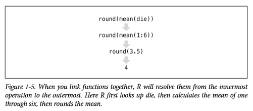

```r
#https://rstudio-education.github.io/hopr/basics.html#objects
```

If you’re not sure which names to use with a function, you can look up the function’s arguments with args. To do this, place the name of the function in the parentheses behind `args`. For example, you can see that the round function takes two arguments, one named x and one named digits:

```r
round(3.444)
```

```
[1] 3
```

```r
  args(round) ## function (x, digits = 0) ## NULL
```

```
function (x, digits = 0)
NULL
```

**Sample with Replacement:**

Sampling with replacement is an easy way to create independent random samples. Each value in your sample will be a sample of size one that is independent of the other values. This is the correct way to simulate a pair of dice:

```r
die<-1:8
sample(die, size = 2, replace = TRUE)
```

```
[1] 5 5
```

```r
dice <- sample(die, size = 2, replace = TRUE)
dice
```

```
[1] 8 6
```

```r
sum(dice)
```

```
[1] 14
```

What would happen if you call dice multiple times? Would R generate a new pair of dice values each time? Let’s give it a try:

```r
dice
```

[output not shown]

```r
dice
```

[output not shown]

```r
dice
```

[output not shown]

Nope. Each time you call dice, R will show you the result of that one time you called sample and saved the output to dice. R won’t rerun `sample(die, 2, replace = TRUE)` to create a new roll of the dice. This is a relief in a way. Once you save a set of results to an R object, those results do not change. Programming would be quite hard if the values of your objects changed each time you called them.

**Writing Your Own Functions:**

To recap, you already have working R code that simulates rolling a pair of dice:

```r
die <- 1:6
dice <- sample(die, size = 2, replace = TRUE)
sum(dice)
```

```
[1] 7
```

It would be easier to use your code if you wrapped it into its own function. Functions may seem mysterious or fancy, but they are just another type of R object. Instead of containing data, they contain code. This code is stored in a special format that makes it easy to reuse the code in new situations. You can write your own functions by recreating this format.

**The Function Constructor:**

Every function in R has three basic parts:

1. a name
2. a body of code, and
3. a set of arguments

> my_function <- function() {}

```r
roll <- function() {
      die <- 1:6
      dice <- sample(die, size = 2, replace = TRUE)
      sum(dice)
      }
    roll()
```

```
[1] 9
```

```r
    roll
```

```
function() {
      die <- 1:6
      dice <- sample(die, size = 2, replace = TRUE)
      sum(dice)
      }
```

**Arguments:**

```r
 roll2 <- function(bones = 1:6) {
      dice <- sample(bones, size = 2, replace = TRUE)
      sum(dice)
      }


    roll2()
```

```
[1] 5
```

```r
    roll2
```

```
function(bones = 1:6) {
      dice <- sample(bones, size = 2, replace = TRUE)
      sum(dice)
      }
```

Finally, you give your function a name by saving its output to an R object, as shown in Figure 2-6.

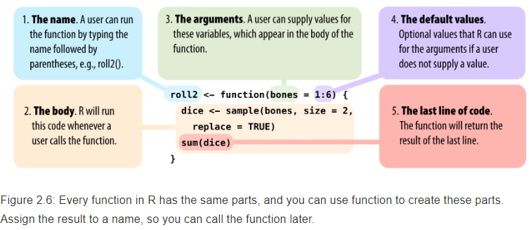

```r
#https://rstudio-education.github.io/hopr/basics.html#objects
```

**Scripts:**

You can open an R script in RStudio by going to File > New File > R script in the menu bar. RStudio will then open a fresh script above your console pane, as shown in Figure 1-7. Figure 1-8.

[figure not shown]

```r
#https://rstudio-education.github.io/hopr/basics.html#objects
```

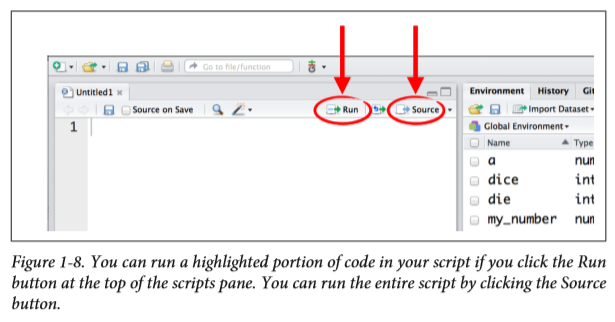

```r
#https://rstudio-education.github.io/hopr/basics.html#objects
```

**Summary:**

The two most important components of the R language are

1. objects, which store data, and
2. functions, which manipulate data. You’ll also look at two of the most useful components of the R language.

R packages, which are collections of functions writted by R’s talented community of developers, and R documentation, which is a collection of help pages built into R that explains every function and data set in the language.

# 2. Packages and Help Pages

Many of the most useful R tools come in R packages, so let’s take a moment to look at what R packages are and how you can use them.

**Packages:**

You’re not the only person writing your own functions with R. Many professors, programmers, and statisticians use R to design tools that can help people analyze data. They then make these tools free for anyone to use. `Appendix 2: R Packages` contains detailed instructions for downloading and updating R packages.

We’re going to use the `qplot` function to make some quick plots. qplot comes in the `ggplot2` package, a popular package for making graphs. Before you can use `qplot`, or anything else in the `ggplot2` package, you need to download and install it.

**Install.packages:**

Each R package is hosted at http://cran.r-project.org, the same website that hosts R. However, you don’t need to visit the website to download an R package; You can download packages straight from R’s command line in RStudio.

Here’s how:

1. Open RStudio.
2. Make sure you are connected to the Internet.
3. Run `install.packages("ggplot2")` at the command line.

**library:**

Installing a package doesn’t place its functions at your fingertips just yet: It simply places them in your hard drive. To use an R package, you next have to load it in your R session with the command `library("ggplot2")`.

The main thing to remember is that you only need to install a package once, but you need to load it with library each time you wish to use it in a new R session. R will unload all of its packages each time you close RStudio.

The following code will make the plot that appears in Figure 2-1.

```r
x <- c(-1, -0.8, -0.6, -0.4, -0.2, 0, 0.2, 0.4, 0.6, 0.8, 1)
x
```

```
 [1] -1.0 -0.8 -0.6 -0.4 -0.2  0.0  0.2  0.4  0.6  0.8  1.0
```

```r
## -1.0 -0.8 -0.6 -0.4 -0.2  0.0  0.2  0.4  0.6  0.8  1.0
y <- x^3
y
```

```
 [1] -1.000 -0.512 -0.216 -0.064 -0.008  0.000  0.008  0.064  0.216  0.512  1.000
```

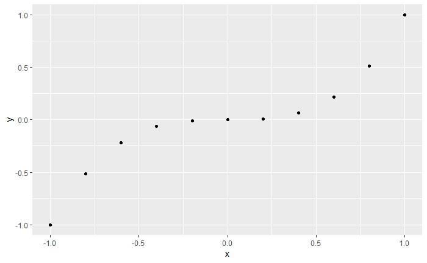

```r
## -1.000 -0.512 -0.216 -0.064 -0.008  0.000  0.008
##  0.064  0.216  0.512  1.000
qplot(x, y)
```

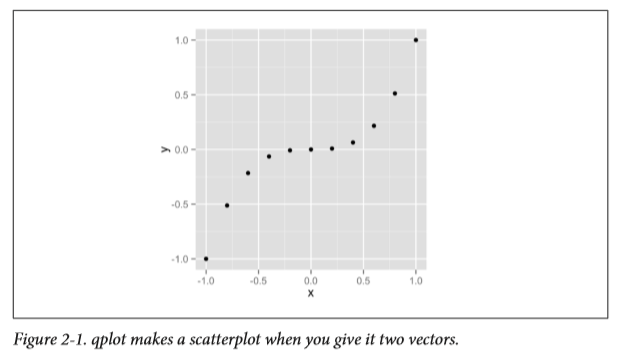

```r
#https://rstudio-education.github.io/hopr/basics.html#objects
```

Give c all of the numbers that you want to appear in the vector, separated by a comma. c stands for concatenate, but you can think of it as “collect” or “combine”:

```r
x <- c(-1, -0.8, -0.6, -0.4, -0.2, 0, 0.2, 0.4, 0.6, 0.8, 1)
x ## -1.0 -0.8 -0.6 -0.4 -0.2  0.0  0.2  0.4  0.6  0.8  1.0
```

```
 [1] -1.0 -0.8 -0.6 -0.4 -0.2  0.0  0.2  0.4  0.6  0.8  1.0
```

```r
y <- x^3
y ## -1.000 -0.512 -0.216 -0.064 -0.008  0.000  0.008 ##  0.064  0.216  0.512  1.000
```

```
 [1] -1.000 -0.512 -0.216 -0.064 -0.008  0.000  0.008  0.064  0.216  0.512  1.000
```

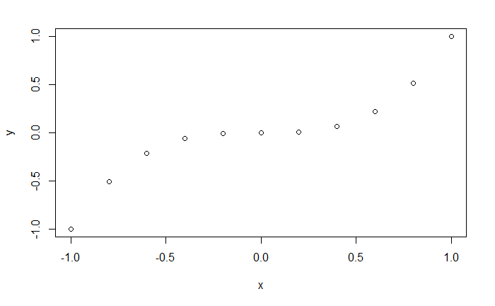

```r
plot(x, y)
```

The following code makes the left-hand plot in Figure 2-2 (we’ll worry about the right-hand plot in just second). To make sure our graphs look the same, use the extra argument binwidth = 1:

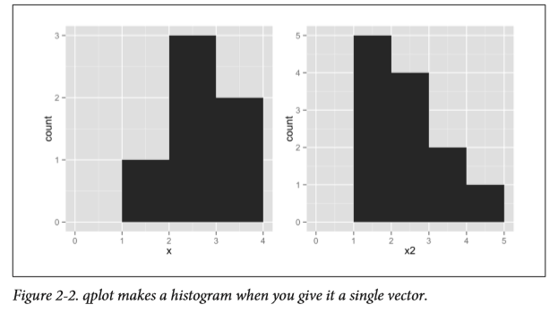

```r
#https://rstudio-education.github.io/hopr/basics.html#objects
```

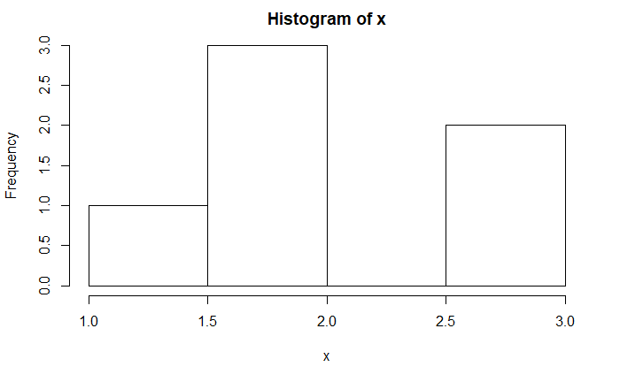

```r
x <- c(1, 2, 2, 2, 3, 3)
hist(x, binwidth = 1)
```

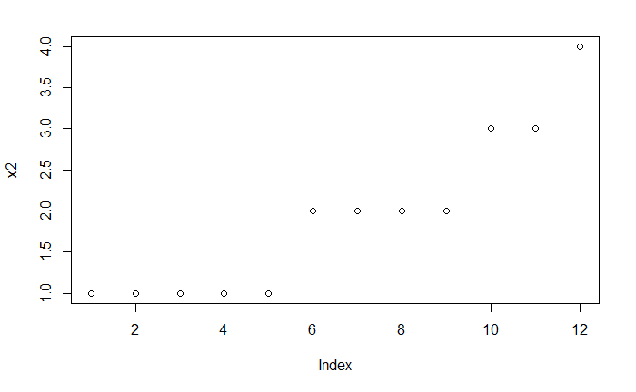

```r
x2 <- c(1, 1, 1, 1, 1, 2, 2, 2, 2, 3, 3, 4)
plot(x2, binwidth = 1)
```

**Exercise_1:**

Let x3 be the following vector:

```r
x3 <- c(0, 1, 1, 2, 2, 2, 3, 3, 4)
x3
```

```
[1] 0 1 1 2 2 2 3 3 4
```

- Imagine what a histogram of x3 would look like.
- Assume that the histogram has a bin width of 1.
- How many bars will the histogram have?
- Where will they appear?
- How high will each be? When you are done, plot a histogram of x3 with binwidth = 1, and see if you are right.

How can you use a histogram to check the accuracy of your dice? Well, if you roll your dice many times and keep track of the results, you would expect some numbers to occur more than others. This is because there are more ways to get some numbers by adding two dice together than to get other numbers, as shown in Figure 2-3.

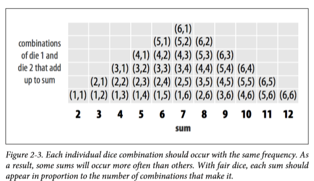

```r
#https://rstudio-education.github.io/hopr/basics.html#objects
```

This is where replicate comes in. Replicate provides an easy way to repeat an R command many times. To use it, first give replicate the number of times you wish to repeat an R command, and then give it the command you wish to repeat. Replicate will run the command multiple times and store the results as a vector:

```r
roll <- function() {
      die <- 1:6
      dice <- sample(die, size = 2, replace = TRUE)
      sum(dice)
      }
replicate(3, 1 + 1)
```

```
[1] 2 2 2
```

```r
replicate(10, roll())
```

```
 [1]  7 11  7 11  5  6  8  4 10  6
```

So let’s simulate 10,000 dice rolls and plot the results. Don’t worry; qplot and replicate can handle it. Figure 2-4:

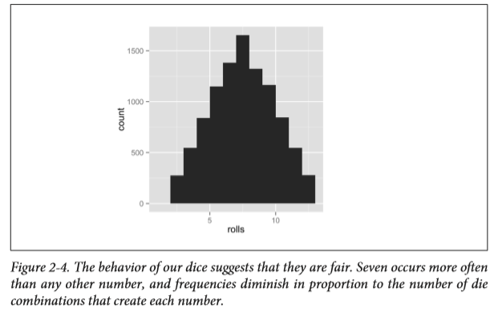

```r
#https://rstudio-education.github.io/hopr/basics.html#objects
```

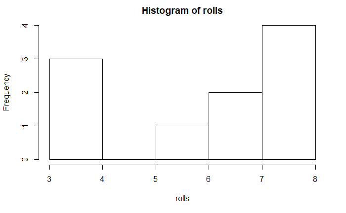

```r
roll <- function() {
    die <- 1:6
    dice <- sample(die, size = 2, replace = TRUE)
    sum(dice)
  }
  rolls <- replicate(10, roll())
  hist(rolls, binwidth = 1)
```

```r
rolls
```

```
 [1] 8 8 4 3 6 7 8 8 7 3
```

See `Appendix B` and `Appendix C`

**Getting Help with Help Pages:**

There are over 1,000 functions at the core of R, and new R functions are created all of the time. This can be a lot of material to memorize and learn! Luckily, each R function comes with its own help page, which you can access by typing the function’s name after.

```r
?sqrt
?log10
?sample
```

Here, almost every help page includes some example code that puts the function in action. Running this code is a great way to learn by example.

> Note: If a function comes in an R package, R won’t be able to find its help page unless the package is loaded.

**Parts of a Help Page:**

Each help page is divided into sections. Which sections appear can vary from help page to help page, but you can usually expect to find these useful topics:

- -Description
- -Usage
- -Arguments
- -Details
- -Value

If you’d like to look up the help page for a function but have forgotten the function’s name, you can search by keyword.

To do this, type two question marks followed by a keyword in R’s command line. R will pull up a list of links to help pages related to the keyword. You can think of this as the help page for the help page:

```r
??log
```

**Exercise_2:**

Rewrite the roll function to roll a pair of weighted dice:

```r
roll <- function() {
    die <- 1:6
    dice <- sample(die, size = 2, replace = TRUE)
    sum(dice)
    }
```

You will need to add a `prob` argument to the sample function inside of roll. This argument should tell sample to sample the numbers one through five with probability 1/8 and the number 6 with probability 3/8.

```r
roll <- function() {
       die <- 1:6
       dice <- sample(die, size = 2, replace = TRUE,    prob = c(1/8, 1/8, 1/8, 1/8, 1/8, 3/8))

       sum(dice)
       }
roll()
```

```
[1] 7
```

This will cause roll to pick 1 through 5 with probability 1/8 and 6 with probability 3/8.

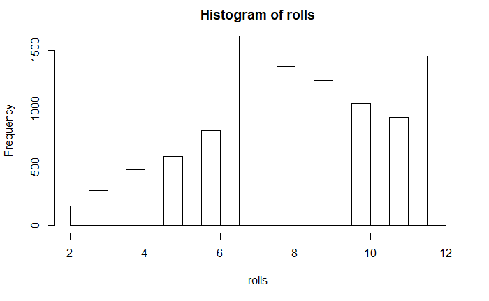

```r
rolls <- replicate(10000, roll())
hist(rolls, binwidth = 1)
```

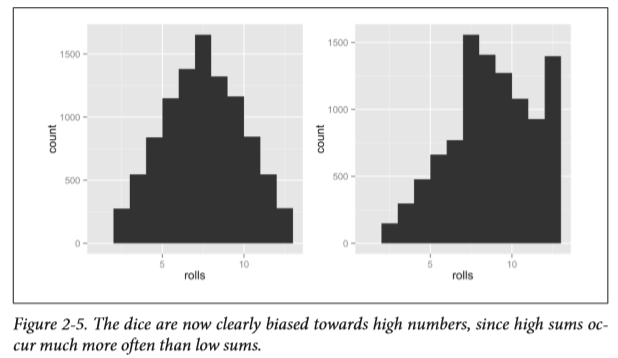

```r
#https://rstudio-education.github.io/hopr/basics.html#objects
```

**Getting More Help:**

- R also comes with a super active community of users that you can turn to for help on the R-help mailing list. https://community.rstudio.com/
- You can email the list with questions, but there’s a great chance that your question has already been answered.
- Find out by searching the archives.

Even better than the R-help list is `Stack Overflow`, a website that allows programmers to answer questions and users to rank answers based on helpfulness.

**Summary:**

- R’s packages and help pages can make you a more productive programmer.
- Often the function that you want to write will already exist in an R package.
- `install.packages`, and then load it into each new R session with `library` for using package.
- R’s help pages will help you master the functions that appear in R and its packages.

# ==Project 2: Playing Cards==

How to store, retrieve, and change data values in your computer’s memory. These skills will help you save and manage data without accumulating errors.

Along the way, you will learn how to:

- Save new types of data, like character strings and logical values
- Save a data set as a vector, matrix, array, list, or data frame
- Load and save your own data sets with R
- Extract individual values from a data set
- Change individual values within a data set
- Write logical tests
- Use R’s missing-value symbol, NA

We’ve divided it into four tasks. Each task will teach you a new skill for managing data with R:

**Task 1: build the deck** In R Objects, you will design and build a virtual deck of playing cards. This will be a complete data set, just like the ones you will use as a data scientist. You’ll need to know how to use R’s data types and data structures to make this work.

**Task 2: write functions that deal and shuffle** Next, in R Notation, you will write two functions to use with the deck. One function will deal cards from the deck, and the other will reshuffle the deck. To write these functions, you’ll need to know how to extract values from a data set with R.

**Task 3: change the point system to suit your game** In Modifying Values, you will use R’s notation system to change the point values of your cards to match the card games you may wish to play, like war, hearts, or blackjack. This will help you change values in place in existing data sets.

**Task 4: manage the state of the deck** Finally, in Environments, you will make sure that your deck remembers which cards it has dealt. This is an advanced task, and it will introduce R’s environment system and scoping rules. To do it successfully, you will need to learn the minute details of how R looks up and uses the data that you have stored in your computer.

# 3. R Objects

**Atomic Vectors:**

You can make an atomic vector by grouping some values of data together with `c`:

```r
die <- c(1, 2, 3, 4, 5, 6)
die
```

```
[1] 1 2 3 4 5 6
```

```r
is.vector(die)
```

```
[1] TRUE
```

```r
#is.vector tests whether an object is an atomic vector.
#It returns TRUE if the object is an atomic vector and FALSE otherwise.
```

You can also make an atomic vector with just one value. R saves single values as an atomic vector of length 1:

```r
five <- 5
five ## 5
```

```
[1] 5
```

```r
is.vector(five)
```

```
[1] TRUE
```

```r
##  TRUE
length(five)
```

```
[1] 1
```

```r
## 1
length(die)
```

```
[1] 6
```

```r
## 6
#!!!length returns the length of an atomic vector.
```

Each atomic vector stores its values as a one-dimensional vector, and each atomic vector can only store one type of data. You can save different types of data in R by using different types of atomic vectors. Altogether, R recognizes six basic types of atomic vectors: doubles, integers, characters, logicals, complex, and raw.

You can do this by using some simple conventions when you enter your data. For example, you can create an integer vector by including a capital L with your input. You can create a character vector by surrounding your input in quotation marks:

```r
int <- 1L
int
```

```
[1] 1
```

```r
text <- "ace"
text
```

```
[1] "ace"
```

If you’d like to make atomic vectors that have more than one element in them, you can combine an element with the `c` function.

```r
int <- c(1L, 5L)
text <- c("ace", "hearts")
```

You may wonder why R uses multiple types of vectors. Vector types help R behave as you would expect. For example, R will do math with atomic vectors that contain numbers, but not with atomic vectors that contain character strings:

```r
sum(int) ## 6
```

```
[1] 6
```

```r
sum(text) ## Error in sum(text) : invalid 'type' (character) of argument
```

```
Error in sum(text) : invalid 'type' (character) of argument
```

But we’re getting ahead of ourselves! Get ready to say hello to the **six types of atomic vectors in R**.

- 1-Doubles

```r
die <- c(1, 2, 3, 4, 5, 6)
die ## 1 2 3 4 5 6
```

```
[1] 1 2 3 4 5 6
```

```r
typeof(die) ##  "double"
```

```
[1] "double"
```

- 2-Integers

```r
int <- c(-1L, 2L, 4L)
    int ## -1  2  4
```

```
[1] -1  2  4
```

```r
    typeof(int) ## "integer"
```

```
[1] "integer"
```

- 3-Characters

```r
text <- c("Hello",  "World")
    text ##  "Hello"  "World"
```

```
[1] "Hello" "World"
```

```r
    typeof(text) ## "character"
```

```
[1] "character"
```

```r
    typeof("Hello") ## "character"
```

```
[1] "character"
```

- 4-Logicals

```r
3 > 4
```

```
[1] FALSE
```

```r
    ## FALSE

    logic <- c(TRUE, FALSE, TRUE)
    logic ##   TRUE FALSE  TRUE
```

```
[1]  TRUE FALSE  TRUE
```

```r
    typeof(logic) ## "logical"
```

```
[1] "logical"
```

```r
    typeof(F) ## "logical"
```

```
[1] "logical"
```

- 5-Complex

```r
x <- 1
y <- 1

comp<- complex(real = x, imaginary = y)

typeof(comp) ## "complex"
```

```
[1] "complex"
```

- 6-Raw

Raw vectors store raw bytes of data. Making raw vectors gets complicated, but you can make an empty raw vector of length n with raw(n). See the help page of raw for more options when working with this type of data:

```r
#Raw vectors store raw bytes of data. Making raw vectors gets complicated,
    #but you can make an empty raw vector of length n with raw(n).
    #See the help page of raw for more options when working with this type of data:

    raw(3)
```

```
[1] 00 00 00
```

```r
      ## 00 00 00
    typeof(raw(3))
```

```
[1] "raw"
```

```r
    ## "raw"
```

- Exercise

Create an atomic vector that stores just the face names of the cards in a royal flush, for example, the ace of spades, king of spades, queen of spades, jack of spades, and ten of spades. The face name of the ace of spades would be “ace,” and “spades” is the suit. Which type of vector will you use to save the names?

```r
hand <- c("ace", "king", "queen", "jack", "ten")
    hand
```

```
[1] "ace"   "king"  "queen" "jack"  "ten"
```

```r
    ## "ace"   "king"  "queen" "jack"  "ten"
    typeof(hand)
```

```
[1] "character"
```

```r
    ## "character"
```

**Attributes:**

You can think of an attribute as “metadata”; it is just a convenient place to put information associated with an object.

```r
die <- c(1, 2, 3, 4, 5, 6)
attributes(die)
```

```r
  ## NULL
```

The most common attributes to give an atomic vector are names, dimensions (dim), and classes.

Note: R uses NULL to represent the null set, an empty object. NULL is often returned by functions whose values are undefined. You can create a NULL object by typing NULL in capital letters.

- Names:

```r
die <- c(1, 2, 3, 4, 5, 6)
names(die) ## NULL
```

```r
names(die) <- c("one", "two", "three", "four", "five", "six")
names(die) ## "one"   "two"   "three" "four"  "five"  "six"
```

```
[1] "one"   "two"   "three" "four"  "five"  "six"
```

```r
attributes(die)
```

```
$names
[1] "one"   "two"   "three" "four"  "five"  "six"
```

R will display the names above the elements of die whenever you look at the vector:

```r
 die
```

```
  one   two three  four  five   six
    1     2     3     4     5     6
```

To remove the names attribute, set it to NULL:

```r
names(die) <- NULL
  die
```

```
[1] 1 2 3 4 5 6
```

- Dim:

You can transform an atomic vector into an n-dimensional array by giving it a dimensions attribute with dim.

```r
die <- c(1, 2, 3, 4, 5, 6)
  dim(die) <- c(2, 3)
die
```

```
     [,1] [,2] [,3]
[1,]    1    3    5
[2,]    2    4    6
```

```r
dim(die) <- c(3, 2)
die
```

```
     [,1] [,2]
[1,]    1    4
[2,]    2    5
[3,]    3    6
```

```r
dim(die) <- c(1, 2, 3)
die
```

```
, , 1

     [,1] [,2]
[1,]    1    2

, , 2

     [,1] [,2]
[1,]    3    4

, , 3

     [,1] [,2]
[1,]    5    6
```

For example, R always fills up each matrix by columns, instead of by rows. If you’d like more control over this process, you can use one of R’s helper functions, matrix or array. They do the same thing as changing the dim attribute, but they provide extra arguments to customize the process.

**Matrices:**

```r
die <- c(1, 2, 3, 4, 5, 6)
m <- matrix(die, nrow = 2)
m
```

```
     [,1] [,2] [,3]
[1,]    1    3    5
[2,]    2    4    6
```

Matrix will fill up the matrix column by column by default, but you can fill the matrix row by row if you include the argument `byrow = TRUE`:

```r
mm <- matrix(die, nrow = 2, byrow = TRUE)
mm
```

```
     [,1] [,2] [,3]
[1,]    1    2    3
[2,]    4    5    6
```

**Arrays:**

The array function creates an n-dimensional Matrix.

```r
ar <- array(c(11:14, 21:24, 31:34), dim = c(2, 2, 3))
ar
```

```
, , 1

     [,1] [,2]
[1,]   11   13
[2,]   12   14

, , 2

     [,1] [,2]
[1,]   21   23
[2,]   22   24

, , 3

     [,1] [,2]
[1,]   31   33
[2,]   32   34
```

Exercise:

Create the following matrix, which stores the name and suit of every card in a royal flush.

```r
hand1 <- c("ace", "king", "queen", "jack", "ten", "spades", "spades",  "spades", "spades", "spades")
matrix(hand1, nrow = 5)
```

```
     [,1]    [,2]
[1,] "ace"   "spades"
[2,] "king"  "spades"
[3,] "queen" "spades"
[4,] "jack"  "spades"
[5,] "ten"   "spades"
```

```r
matrix(hand1, ncol = 2)
```

```
     [,1]    [,2]
[1,] "ace"   "spades"
[2,] "king"  "spades"
[3,] "queen" "spades"
[4,] "jack"  "spades"
[5,] "ten"   "spades"
```

```r
dim(hand1) <- c(5, 2)
hand1
```

```
     [,1]    [,2]
[1,] "ace"   "spades"
[2,] "king"  "spades"
[3,] "queen" "spades"
[4,] "jack"  "spades"
[5,] "ten"   "spades"
```

```r
test<-matrix(hand1,nrow=5, ncol=2)
test
```

```
     [,1]    [,2]
[1,] "ace"   "spades"
[2,] "king"  "spades"
[3,] "queen" "spades"
[4,] "jack"  "spades"
[5,] "ten"   "spades"
```

**Class:**

```r
class("Hello")
```

```
[1] "character"
```

```r
##  "character"
class(5) ##
```

```
[1] "numeric"
```

```r
"numeric"
```

```
[1] "numeric"
```

- Dates and Times:

```r
now <- Sys.time()
now
```

```
[1] "2019-04-14 11:35:59 CEST"
```

```r
typeof(now) ##  "double"
```

```
[1] "double"
```

```r
class(now) ## "POSIXct" "POSIXt"
```

```
[1] "POSIXct" "POSIXt"
```

- Factors:

Factors are R’s way of storing categorical information, like ethnicity or eye color. Think of a factor as something like a gender; it can only have certain values (male or female).

```r
gender <- factor(c("male", "female", "female", "male"))
gender
```

```
[1] male   female female male
Levels: female male
```

```r
typeof(gender)
```

```
[1] "integer"
```

```r
attributes(gender)
```

```
$levels
[1] "female" "male"

$class
[1] "factor"
```

You can see exactly how R is storing your factor with unclass:

```r
gender <- factor(c("male", "female", "female", "male"))
unclass(gender)
```

```
[1] 2 1 1 2
attr(,"levels")
[1] "female" "male"
```

```r
gender
```

```
[1] male   female female male
Levels: female male
```

Factors make it easy to put categorical variables into a statistical model because the variables are already coded as numbers. However, factors can be confusing since they look like character strings but behave like integers.

```r
gender <- factor(c("male", "female", "female", "male"))
as.character(gender)
```

```
[1] "male"   "female" "female" "male"
```

Exercise:

Many card games assign a numerical value to each card. For example, in blackjack, each face card is worth 10 points, each number card is worth between 2 and 10 points, and each ace is worth 1 or 11 points, depending on the final score. Make a virtual playing card by combining “ace,” “heart,” and 1 into a vector. What type of atomic vector will result? Check if you are right.

You can convert a factor to a character string with the `as.character function`. R will retain the display version of the factor, not the integers stored in memory:

```r
card <- c("ace", "hearts", 1)
card
```

[output not shown]

This will cause trouble if you want to do math with that point value, for example, to see who won your game of blackjack. Since matrices and arrays are special cases of atomic vectors, they suffer from the same behavior. Each can only store one type of data. This creates a couple of problems. First, many data sets contain multiple types of data. Simple programs like Excel and Numbers can save multiple types of data in the same data set, and you should hope that R can too. Don’t worry, it can.

**Coercion:**

Figure 3-1.

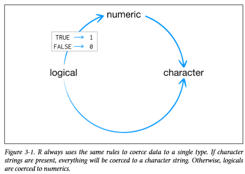

R uses the same coercion rules when you try to do math with logical values. So the following code:

```r
sum(c(TRUE, TRUE, FALSE, FALSE))
```

```
[1] 2
```

```r
#will become:
sum(c(1, 1, 0, 0))
```

```
[1] 2
```

You can explicitly ask R to convert data from one type to another with the as functions. R will convert the data whenever there is a sensible way to do so:

```r
as.character(1)
```

```
[1] "1"
```

```r
  ## "1"
as.logical(1)
```

```
[1] TRUE
```

```r
  ## TRUE
as.numeric(FALSE)
```

```
[1] 0
```

```r
  ## 0
```

**Lists:**

Lists are like atomic vectors because they group data into a one-dimensional set. However, lists do not group together individual values; lists group together R objects, such as atomic vectors and other lists.

```r
list1 <- list(100:130, "R", list(TRUE, FALSE))
print(list1)
```

```
[[1]]
 [1] 100 101 102 103 104 105 106 107 108 109 110 111 112 113 114 115 116 117 118 119 120 121 122
[24] 123 124 125 126 127 128 129 130

[[2]]
[1] "R"

[[3]]
[[3]][[1]]
[1] TRUE

[[3]][[2]]
[1] FALSE
```

Exercise:

Use a list to store a single playing card, like the ace of hearts, which has a point value of one. The list should save the face of the card, the suit, and the point value in separate elements.

```r
card <- list("ace", "hearts", 1)
print(card)
```

```
[[1]]
[1] "ace"

[[2]]
[1] "hearts"

[[3]]
[1] 1
```

**Data Frames:**

You can think of a data frame as R’s equivalent to the Excel spreadsheet because it stores data in a similar format. Data frames group vectors together into a two-dimensional table. Each vector becomes a column in the table. As a result, each column of a data frame can contain a different type of data; but within a column, every cell must be the same type of data, as in Figure 3-2.

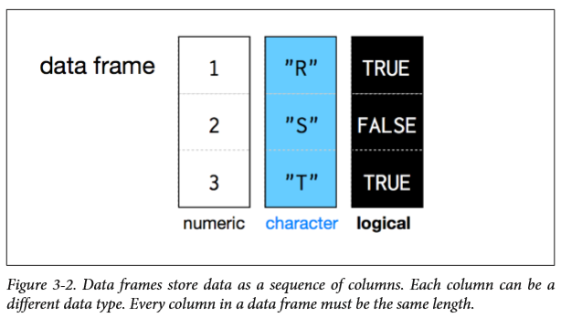

```r
df <- data.frame(face = c("ace", "two", "six"),  suit = c("clubs", "clubs", "clubs"), value = c(1, 2, 3))
df
```

| face | suit | value |
| --- | --- | --- |
| ace | clubs | 1 |
| two | clubs | 2 |
| six | clubs | 3 |

In fact, each data frame is a list with class `data.frame`.

```r
typeof(df)
```

```
[1] "list"
```

```r
class(df)
```

```
[1] "data.frame"
```

```r
str(df)
```

```
'data.frame':   3 obs. of  3 variables:
 $ face : Factor w/ 3 levels "ace","six","two": 1 3 2
 $ suit : Factor w/ 1 level "clubs": 1 1 1
 $ value: num  1 2 3
```

Notice that R saved your character strings as factors. R likes factors! It is not a very big deal here, but you can prevent this behavior by adding the argument stringsAsFactors = FALSE to data.frame:

```r
df <- data.frame(face = c("ace", "two", "six"),  suit = c("clubs", "clubs", "clubs"), value = c(1, 2, 3),  stringsAsFactors = FALSE)
df
```

| face | suit | value |
| --- | --- | --- |
| ace | clubs | 1 |
| two | clubs | 2 |
| six | clubs | 3 |

You should avoid typing large data sets in by hand whenever possible. Typing invites typos and errors, not to mention RSI. It is always better to acquire large data sets as a computer file. You can then ask R to read the file and store the contents as an object.

**Loading Data:**

Dataset: https://gist.github.com/garrettgman/9629323

- Most data-science applications can open plain-text files and export data as plain-text files.
- This makes plain-text files a sort of lingua franca for data science.
- To load a plain-text file into R, click the Import Dataset icon in RStudio, shown in Figure 3-3.
- Then select “From text file.”

[figure not shown]

```r
deck
```

| face | suit | value |
| --- | --- | --- |
| king | spades | 13 |
| queen | spades | 12 |
| jack | spades | 11 |
| ten | spades | 10 |
| nine | spades | 9 |
| eight | spades | 8 |
| seven | spades | 7 |
| six | spades | 6 |
| five | spades | 5 |
| four | spades | 4 |

[output cut: 42 more lines]

```r
class(deck)
```

```
[1] "data.frame"
```

Once everything looks right, click Import. RStudio will read in the data and save it to a data frame. RStudio will also open a data viewer, so you can see your new data in a spreadsheet format. This is a good way to check that everything came through as expected.

**Saving Data:**

You can save any data frame in R to a .csv file with the command write.csv. To save deck, run:

`write.csv(deck, file = “cards.csv”, row.names = FALSE)``

R will turn your data frame into a plain-text file with the comma-separated values format and save the file to your working directory. To see where your working directory is, run `getwd()`.

```r
getwd()
```

```
[1] "C:/Users/cevi herdian/Documents/MEGA/Data-Sciences/R Programming/tutorial/Hands On Programming with R/Github/hopr"
```

To change the location of your working directory, visit `Session > Set Working Directory > Choose Directory` in the RStudio menu bar.

**Summary:**

You can save data in R with five different objects, which let you store different types of values in different types of relationships, as in Figure 3-6. Data frames store one of the most common forms of data used in data science, tabular data. You can load tabular data into a data frame with RStudio’s Import Dataset button-so long as the data is saved as a plain-text file. No program is better at converting Excel files than Excel. Similarly, no program is better at converting SAS Xport files than SAS, and so on.

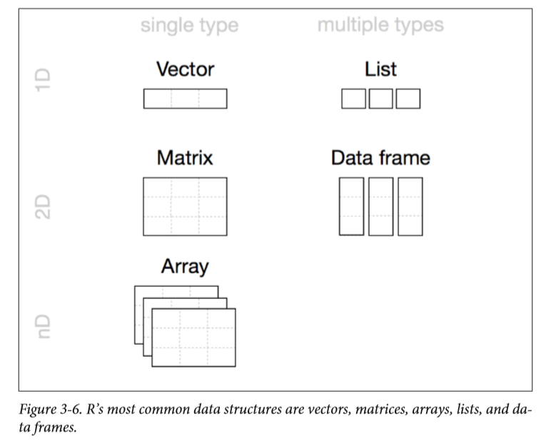

- 6 types R atomic vectors:
1. Integers
2. Double
3. Logic
4. Characters
5. Complexs
6. Raw
- 5 R objects:
1. Vectors
2. Matrix
3. Arrays
4. List
5. Data Frame

See the `Appendix D`

# 4. R Notation

**Selecting Values:**

First of all, import the deck.csv. To extract a value or set of values from a data frame, write the data frame’s name followed by a pair of hard brackets:

```r
deck
```

| face | suit | value |
| --- | --- | --- |
| king | spades | 13 |
| queen | spades | 12 |
| jack | spades | 11 |
| ten | spades | 10 |
| nine | spades | 9 |
| eight | spades | 8 |
| seven | spades | 7 |
| six | spades | 6 |
| five | spades | 5 |
| four | spades | 4 |

[output cut: 42 more lines]

```r
class(deck)
```

```
[1] "data.frame"
```

```r
deck[ , ]
```

| face | suit | value |
| --- | --- | --- |
| king | spades | 13 |
| queen | spades | 12 |
| jack | spades | 11 |
| ten | spades | 10 |
| nine | spades | 9 |
| eight | spades | 8 |
| seven | spades | 7 |
| six | spades | 6 |
| five | spades | 5 |
| four | spades | 4 |

[output cut: 42 more lines]

You have a choice when it comes to writing indexes. There are six different ways to write an index for R, and each does something slightly different.

1. Positive integers
2. Negative integers
3. Zero
4. Blank spaces
5. Logical values
6. Names

The simplest of these to use is positive integers.

1. Positive Integers

R treats positive integers just like ij notation in linear algebra: `deck[i,j]` will return the value of deck that is in the ith row and the jth column, Figure 4-1.

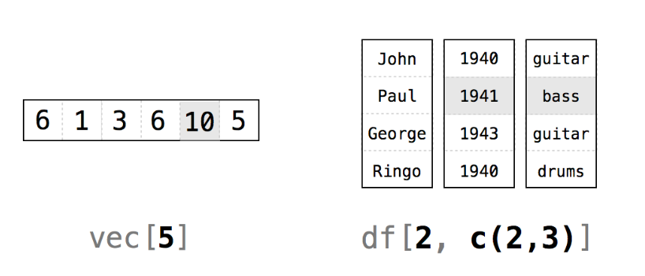

```r
deck[1, 1]
```

```
[1] king
Levels: ace eight five four jack king nine queen seven six ten three two
```

To extract more than one value, use a vector of positive integers. For example, you can return the first row of deck with deck[1, c(1, 2, 3)] or deck[1, 1:3]:

```r
deck[1, c(1, 2, 3)]
```

|  | face | suit | value |
| --- | --- | --- | --- |
| 1 | king | spades | 13 |

R will give you a new set of values which are copies of the original values. You can then save this new set to an R object with R’s assignment operator:

```r
new <- deck[1, c(1, 2, 3)]
new
```

|  | face | suit | value |
| --- | --- | --- | --- |
| 1 | king | spades | 13 |

R’s notation system is not limited to data frames. You can use the same syntax to select values in any R object, as long as you supply one index for each dimension of the object. So, for example, you can subset a vector (which has one dimension) with a single index:

```r
vec <- c(6, 1, 3, 6, 10, 5)
vec[1:3]
```

```
[1] 6 1 3
```

2. Negative Integers

Negative integers do the exact opposite of positive integers when indexing. R will return every element except the elements in a negative index.

```r
deck[-(2:52), 1:3]
```

|  | face | suit | value |
| --- | --- | --- | --- |
| 1 | king | spades | 13 |

Negative integers are a more efficient way to subset than positive integers if you want to include the majority of a data frame’s rows or columns.

3. Zero

R will return nothing from a dimension when you use zero as an index. This creates an empty object:

```r
deck[0, 0]
```

data frame with 0 columns and 0 rows To be honest, indexing with zero is not very helpful.

4. Blank Spaces

You can use a blank space to tell R to extract every value in a dimension.

```r
deck[1, ]
```

|  | face | suit | value |
| --- | --- | --- | --- |
| 1 | king | spades | 13 |

5. Logical Values

If you supply a vector of TRUEs and FALSEs as your index, R will match each TRUE and FALSE to a row in your data frame (or a column depending on where you place the index). R will then return each row that corresponds to a TRUE, Figure 4-2.

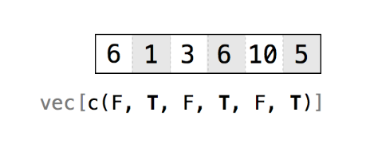

```r
deck[1, c(TRUE, TRUE, FALSE)]
```

|  | face | suit |
| --- | --- | --- |
| 1 | king | spades |

6. Names

Finally, you can ask for the elements you want by name-if your object has names.

```r
deck[1, c("face", "suit", "value")]
```

|  | face | suit | value |
| --- | --- | --- | --- |
| 1 | king | spades | 13 |

**Deal a Card:**

Complete the following code to make a function that returns the first row of a data frame:

```r
deal <- function(cards) {
    cards[1, ]
    }

  deal(deck)
```

|  | face | suit | value |
| --- | --- | --- | --- |
| 1 | king | spades | 13 |

**Shuffle the Deck:**

```r
deck2 <- deck[1:52, ]
  deck2
```

|  | face | suit | value |
| --- | --- | --- | --- |
| 1 | king | spades | 13 |
| 2 | queen | spades | 12 |
| 3 | jack | spades | 11 |
| 4 | ten | spades | 10 |
| 5 | nine | spades | 9 |
| 6 | eight | spades | 8 |
| 7 | seven | spades | 7 |
| 8 | six | spades | 6 |
| 9 | five | spades | 5 |
| 10 | four | spades | 4 |

[output cut: 42 more lines]

```r
  head(deck2)
```

|  | face | suit | value |
| --- | --- | --- | --- |
| 1 | king | spades | 13 |
| 2 | queen | spades | 12 |
| 3 | jack | spades | 11 |
| 4 | ten | spades | 10 |
| 5 | nine | spades | 9 |
| 6 | eight | spades | 8 |

```r
  deck3 <- deck[c(2, 1, 3:52), ]
  deck3
```

|  | face | suit | value |
| --- | --- | --- | --- |
| 2 | queen | spades | 12 |
| 1 | king | spades | 13 |
| 3 | jack | spades | 11 |
| 4 | ten | spades | 10 |
| 5 | nine | spades | 9 |
| 6 | eight | spades | 8 |
| 7 | seven | spades | 7 |
| 8 | six | spades | 6 |
| 9 | five | spades | 5 |
| 10 | four | spades | 4 |

[output cut: 42 more lines]

How could you generate such a random collection of integers? With our friendly neighborhood sample function:

```r
random <- sample(1:52, size = 52)
  random
```

```
 [1] 33 38 48 47 36  5 28  6  2 10 31  4 16 19 39 18  8 52 15 34 23 12  7 42 43 30 14 13 32 40 17
[32] 25 35  3 51 44 26 29 49  9  1 20 21 22 24 37 46 45 41 11 27 50
```

```r
  deck4 <- deck[random, ]
  head(deck4)
```

|  | face | suit | value |
| --- | --- | --- | --- |
| 33 | seven | diamonds | 7 |
| 38 | two | diamonds | 2 |
| 48 | five | hearts | 5 |
| 47 | six | hearts | 6 |
| 36 | four | diamonds | 4 |
| 5 | nine | spades | 9 |

Exercise:

Use the preceding ideas to write a shuffle function. Shuffle should take a data frame and return a shuffled copy of the data frame. Your shuffle function will look like the one that follows:

```r
shuffle <- function(cards) {
    random <- sample(1:52, size = 52)
    cards[random, ]
    }


  deal(deck)
```

|  | face | suit | value |
| --- | --- | --- | --- |
| 1 | king | spades | 13 |

```r
  deck2 <- shuffle(deck)
  deal(deck2)
```

|  | face | suit | value |
| --- | --- | --- | --- |
| 36 | four | diamonds | 4 |

**Dollar Signs and Double Brackets:**

Two types of object in R obey an optional second system of notation. You can extract values from data frames and lists with the $ syntax.

```r
deck$value
```

```
 [1] 13 12 11 10  9  8  7  6  5  4  3  2  1 13 12 11 10  9  8  7  6  5  4  3  2  1 13 12 11 10  9
[32]  8  7  6  5  4  3  2  1 13 12 11 10  9  8  7  6  5  4  3  2  1
```

```r
mean(deck$value)
```

```
[1] 7
```

```r
median(deck$value)
```

```
[1] 7
```

You can use the same $ notation with the elements of a list, if they have names.

```r
lst <- list(numbers = c(1, 2), logical = TRUE, strings = c("a", "b", "c"))
lst
```

```
$numbers
[1] 1 2

$logical
[1] TRUE

$strings
[1] "a" "b" "c"
```

And then subset it:

```r
lst[1]
```

```
$numbers
[1] 1 2
```

```r
lst$numbers
```

```
[1] 1 2
```

```r
lst[[1]]
```

```
[1] 1 2
```

```r
lst[["numbers"]]
```

```
[1] 1 2
```

In the R community, there is a popular, and helpful, way to think about it, Figure 4-3.

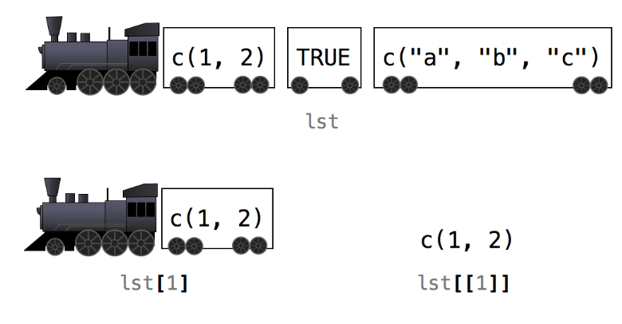

**Summary:**

You have learned how to access values that have been stored in R. You can retrieve a copy of values that live inside a data frame and use the copies for new computations.

# 5. Modifying Values

**Changing Values in Place:**

```r
vec <- c(0, 0, 0, 0, 0, 0)
vec
```

```
[1] 0 0 0 0 0 0
```

Here’s how you can select the first value of vec:

```r
vec[1]
```

```
[1] 0
```

And here is how you can modify it:

```r
vec[1] <- 1000
vec
```

```
[1] 1000    0    0    0    0    0
```

You can replace multiple values at once as long as the number of new values equals the number of selected values:

```r
vec[c(1, 3, 5)] <- c(1, 1, 1)
vec
```

```
[1] 1 0 1 0 1 0
```

```r
vec[4:6] <- vec[4:6] + 1
vec
```

[output not shown]

This provides a great way to add new variables to your data set: firts import the deck.csv

```r
deck
```

| face | suit | value |
| --- | --- | --- |
| king | spades | 13 |
| queen | spades | 12 |
| jack | spades | 11 |
| ten | spades | 10 |
| nine | spades | 9 |
| eight | spades | 8 |
| seven | spades | 7 |
| six | spades | 6 |
| five | spades | 5 |
| four | spades | 4 |

[output cut: 42 more lines]

```r
deck2<-deck
deck2$new <- 1:52
deck2
```

| face | suit | value | new |
| --- | --- | --- | --- |
| king | spades | 13 | 1 |
| queen | spades | 12 | 2 |
| jack | spades | 11 | 3 |
| ten | spades | 10 | 4 |
| nine | spades | 9 | 5 |
| eight | spades | 8 | 6 |
| seven | spades | 7 | 7 |
| six | spades | 6 | 8 |
| five | spades | 5 | 9 |
| four | spades | 4 | 10 |

[output cut: 42 more lines]

You can also remove columns from a data frame (and elements from a list) by assigning them the symbol NULL:

```r
deck2$new <- NULL
  head(deck2)
```

|  | face | suit | value |
| --- | --- | --- | --- |
| 1 | king | spades | 13 |
| 2 | queen | spades | 12 |
| 3 | jack | spades | 11 |
| 4 | ten | spades | 10 |
| 5 | nine | spades | 9 |
| 6 | eight | spades | 8 |

You can single out just the values of the aces by subsetting the columns dimension of deck2. Or, even better, you can subset the column vector deck2$value:

```r
deck2[c(13, 26, 39, 52), 3]
```

```
[1] 1 1 1 1
```

```r
deck2$value[c(13, 26, 39, 52)]
```

```
[1] 1 1 1 1
```

Now all you have to do is assign a new set of values to these old values.

```r
deck2$value[c(13, 26, 39, 52)] <- c(14, 14, 14, 14)
  # or
  deck2$value[c(13, 26, 39, 52)] <- 14
  deck2
```

| face | suit | value |
| --- | --- | --- |
| king | spades | 13 |
| queen | spades | 12 |
| jack | spades | 11 |
| ten | spades | 10 |
| nine | spades | 9 |
| eight | spades | 8 |
| seven | spades | 7 |
| six | spades | 6 |
| five | spades | 5 |
| four | spades | 4 |

[output cut: 42 more lines]

**Logical Subsetting:**

```r
vec <- c(1, 0, 1, 1, 0, 2)
vec
```

```
[1] 1 0 1 1 0 2
```

```r
vec[c(FALSE, FALSE, FALSE, FALSE, TRUE, FALSE, FALSE)]
```

```
[1] 0
```

At first glance, this system might seem impractical. Who wants to type out long vectors of TRUEs and FALSEs? No one. But you don’t have to. You can let a logical test create a vector of TRUEs and FALSEs for you.

**Logical Tests:**

A logical test is a comparison like “is one less than two?”, `1 < 2`, or “is three greater than four?”, `3 > 4`. R provides seven logical operators that you can use to make comparisons, shown in Table 7-1 and Table 7-2.

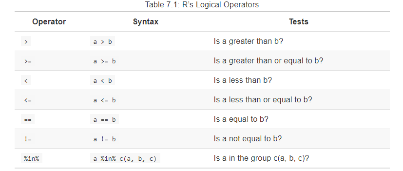

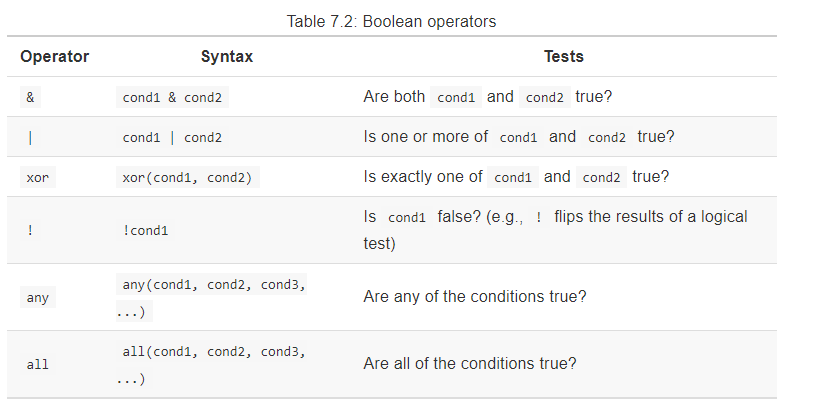

Each operator returns a TRUE or a FALSE. If you use an operator to compare vectors, R will do element-wise comparisons-just like it does with the arithmetic operators:

```r
1 > 2
```

```
[1] FALSE
```

```r
1 > c(0, 1, 2)
```

```
[1]  TRUE FALSE FALSE
```

```r
c(1, 2, 3) == c(3, 2, 1)
```

```
[1] FALSE  TRUE FALSE
```

`%in%` is the only operator that does not do normal element-wise execution. `%in%` tests whether the value(s) on the left side are in the vector on the right side.

```r
1 %in% c(3, 4, 5)
```

```
[1] FALSE
```

```r
c(1, 2) %in% c(3, 4, 5)
```

```
[1] FALSE FALSE
```

```r
c(1, 2, 3) %in% c(3, 4, 5)
```

```
[1] FALSE FALSE  TRUE
```

```r
c(1, 2, 3, 4) %in% c(3, 4, 5)
```

```
[1] FALSE FALSE  TRUE  TRUE
```

Notice that you test for equality with a double equals sign, ==, and not a single equals sign, =, which is another way to write `<-`. You can compare any two R objects with a logical operator; however, logical operators make the most sense if you compare two objects of the same data type. If you compare objects of different data types, R will use its coercion rules to coerce the objects to the same type before it makes the comparison.

**Missing Information:**

Missing information problems happen frequently in data science. The NA character is a special symbol in R. It stands for “not available” and can be used as a placeholder for missing information. Generally, NAs will propagate whenever you use them in an R operation or function. This can save you from making errors based on missing data.

- na.rm:

Missing values can help you work around holes in your data sets, but they can also create some frustrating problems. Suppose, for example, that you’ve collected 1,000 observations and wish to take their average with R’s mean function. If even one of the values is NA, your result will be NA:

```r
c(NA, 1:50)
```

```
 [1] NA  1  2  3  4  5  6  7  8  9 10 11 12 13 14 15 16 17 18 19 20 21 22 23 24 25 26 27 28 29 30
[32] 31 32 33 34 35 36 37 38 39 40 41 42 43 44 45 46 47 48 49 50
```

```r
mean(c(NA, 1:50))
```

```
[1] NA
```

Understandably, you may prefer a different behavior. Most R functions come with the optional argument, na.rm, which stands for NA remove. R will ignore NAs when it evaluates a function if you add the argument `na.rm = TRUE`:

```r
mean(c(NA, 1:50), na.rm = TRUE)
```

```
[1] 25.5
```

- is.na:

On occasion, you may want to identify the NAs in your data set with a logical test, but that too creates a problem. How would you go about it? If something is a missing value, any logical test that uses it will return a missing value, even this test:

```r
NA == NA
```

```
[1] NA
```

Which means that tests like this won’t help you find missing values:

```r
c(1, 2, 3, NA) == NA
```

```
[1] NA NA NA NA
```

But don’t worry too hard; R supplies a special function that can test whether a value is an NA. The function is sensibly named is.na:

```r
is.na(NA) ## TRUE
```

```
[1] TRUE
```

```r
vec <- c(1, 2, 3, NA)
is.na(vec)
```

```
[1] FALSE FALSE FALSE  TRUE
```

Let’s set all of your ace values to NA. This will accomplish two things. First, it will remind you that you do not know the final value of each ace. Second, it will prevent you from accidentally scoring a hand that has an ace before you determine the ace’s final value.

```r
deck5<-deck
deck5$value[deck5$face == "ace"] <- NA
deck5
```

| face | suit | value |
| --- | --- | --- |
| king | spades | 13 |
| queen | spades | 12 |
| jack | spades | 11 |
| ten | spades | 10 |
| nine | spades | 9 |
| eight | spades | 8 |
| seven | spades | 7 |
| six | spades | 6 |
| five | spades | 5 |
| four | spades | 4 |

[output cut: 42 more lines]

**Summary:**

You can modify values in place inside an R object when you combine R’s notation syntax with the assignment operator, `<-`. This lets you update your data and clean your data sets.